# Executive Summary

# data

The data was extracted from the 1974 Motor Trend US magazine, and comprises fuel consumption and 10 aspects of automobile design and performance for 32 automobiles (1973–74 models). description for variable can be find in appendix

```
##                mpg cyl disp  hp drat    wt  qsec vs am gear carb
## Mazda RX4     21.0   6  160 110 3.90 2.620 16.46  0  1    4    4
## Mazda RX4 Wag 21.0   6  160 110 3.90 2.875 17.02  0  1    4    4
## Datsun 710    22.8   4  108  93 3.85 2.320 18.61  1  1    4    1
```

looking at the data we see 11 variables with all numeric value.

Our variables of intrest here are 1. transmition (am) which form the information provided about the data we know that it take value 1 for manual and 0 for automatic. 2. MPG (mile per gallon) which we can see the summary stats for it here

```
##    Min. 1st Qu.  Median    Mean 3rd Qu.    Max.
##   10.40   15.43   19.20   20.09   22.80   33.90
```

It appears that automatic cars have a lower miles per gallon, and therefore a lower fuel efficiency, than manual cars do. But it is possible that this apparent pattern happened by random chance- that is, that we just happened to pick a group of automatic cars with low efficiency and a group of manual cars with higher efficiency. So to check whether that’s the case, we have to use a statistical test.

# Method

To addres the first question we run a simple t-test to test if the automatic cars have a lower miles per gallon our null hypothesis is that there is no diffrenct between the two.

```
##  t.statistic       df     p.value  lower.CL  upper.CL automatic.mean
##    -3.767123 18.33225 0.001373638 -11.28019 -3.209684       17.14737
##  manual.mean
##     24.39231
```

As we can see the the p-value is 0.001 which means that we can reject the null and conclude that automatic cars have a lower miles per gallon Now to quantifying the diffrence between the two we need to have a model, the proper models here could be simple linear regression or multivariable linear regression we conduct both and the select the best model, so that we our predicton be the most accurate one. for selecting the best model one way is to look at the R2 value but to have a better result we conduct a likelihood ratio test and compare the two models.

### Linear regression

| F(1,30) | 16.86 |
| --- | --- |
| R² | 0.36 |
| Adj. R² | 0.34 |

|  | Est. | S.E. | t val. | p |
| --- | --- | --- | --- | --- |
| (Intercept) | 17.15 | 1.12 | 15.25 | 0.00 |
| am | 7.24 | 1.76 | 4.11 | 0.00 |

Standard errors: OLS

both intercept and transmission are significant, and the model shows that mpg for manual car are 7.25 scale higher than autmatic, but if we look at the R2: 0.35 which means only 35 of variance in MPG is actully defined by transmision.

### Multivariate Regression

| F(3,28) | 52.75 |
| --- | --- |
| R² | 0.85 |
| Adj. R² | 0.83 |

|  | Est. | S.E. | t val. | p |
| --- | --- | --- | --- | --- |
| (Intercept) | 9.62 | 6.96 | 1.38 | 0.18 |
| wt | -3.92 | 0.71 | -5.51 | 0.00 |
| qsec | 1.23 | 0.29 | 4.25 | 0.00 |
| am | 2.94 | 1.41 | 2.08 | 0.05 |

Standard errors: OLS

```
## Analysis of Variance Table
##
## Model 1: mpg ~ am
## Model 2: mpg ~ wt + qsec + am
##   Res.Df    RSS Df Sum of Sq      F   Pr(>F)
## 1     30 720.90
## 2     28 169.29  2    551.61 45.618 1.55e-09 ***
## ---
## Signif. codes:  0 '***' 0.001 '**' 0.01 '*' 0.05 '.' 0.1 ' ' 1
```

Finally, in order to intrepret the result we must make sure that the error dosen’t have hetroskesaticity and colinearity this can be find at appandix(figure).

# Conclusion

Using model contruction, we have shown that, adjusted to other strong mpg predictors that we can find in the mtcars dataset, manual transmission is really the best transmission for mpg with mmpg=9.61+2.93 amManual-3.91 wt +1.22 qsec

# Appendix

residual plot and some diagnostics

[, 1] mpg Miles/(US) gallon [, 2] cyl Number of cylinders [, 3] disp Displacement (cu.in.) [, 4] hp Gross horsepower [, 5] drat Rear axle ratio [, 6] wt Weight (1000 lbs) [, 7] qsec 1/4 mile time [, 8] vs Engine (0 = V-shaped, 1 = straight) [, 9] am Transmission (0 = automatic, 1 = manual) [,10] gear Number of forward gears [,11] carb Number of carburetors

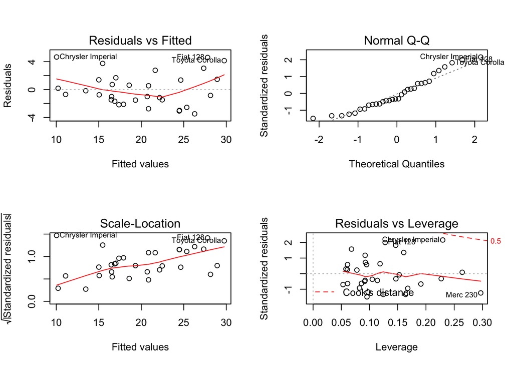